# Practical Machine Learning Course Project

Thomas Young

11/3/2016

## Background

Using devices such as Jawbone Up, Nike FuelBand, and Fitbit it is now possible to collect a large amount of data about personal activity relatively inexpensively. These type of devices are part of the quantified self movement – a group of enthusiasts who take measurements about themselves regularly to improve their health, to find patterns in their behavior, or because they are tech geeks. One thing that people regularly do is quantify how much of a particular activity they do, but they rarely quantify how well they do it. In this project, your goal will be to use data from accelerometers on the belt, forearm, arm, and dumbell of 6 participants. They were asked to perform barbell lifts correctly and incorrectly in 5 different ways. More information is available from the website here: http://groupware.les.inf.puc-rio.br/har (see the section on the Weight Lifting Exercise Dataset).

## Loading the Data

```r
training <- read.csv("pml-training.csv", na.strings = c("NA", "#DIV/0!", ""))
testing <- read.csv("pml-testing.csv",na.strings=c("NA","#DIV/0!"))
```

## Examining the Classes

Taking a look at the various classes in the data

```r
table(training$classe)
```

```
##
##    A    B    C    D    E
## 5580 3797 3422 3216 3607
```

## Viewing the Data in a Table

```r
prop.table(table(training$user_name, training$classe), 1)
```

```
##
##                    A         B         C         D         E
##   adelmo   0.2993320 0.1993834 0.1927030 0.1323227 0.1762590
##   carlitos 0.2679949 0.2217224 0.1584190 0.1561697 0.1956941
##   charles  0.2542421 0.2106900 0.1524321 0.1815611 0.2010747
##   eurico   0.2817590 0.1928339 0.1592834 0.1895765 0.1765472
##   jeremy   0.3459730 0.1437390 0.1916520 0.1534392 0.1651969
##   pedro    0.2452107 0.1934866 0.1911877 0.1796935 0.1904215
```

```r
prop.table(table(training$classe))
```

```
##
##         A         B         C         D         E
## 0.2843747 0.1935073 0.1743961 0.1638977 0.1838243
```

## Cleaning up Data

Revoming columbs 1-6 to get just the data and then removing all the NA’s

```r
training <- training[, 7:160]
testing  <- testing[, 7:160]
```

```r
is_data  <- apply(!is.na(training), 2, sum) > 19621  # which is the number of observations
training <- training[, is_data]
testing  <- testing[, is_data]
```

## Splitting the Data with Partitions

```r
library(caret)
set.seed(3141592)
inTrain <- createDataPartition(y=training$classe, p=0.60, list=FALSE)
train1  <- training[inTrain,]
train2  <- training[-inTrain,]
dim(train1)
```

```
## [1] 11776    54
```

## Modeling

Loading required packages

```r
library(rpart.plot)
library(RGtk2)
library(randomForest)
library(rattle)
dim(train2)
```

```
## [1] 7846   54
```

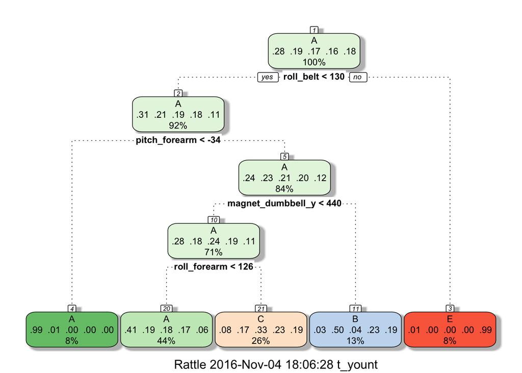

```r
modfit1 <- train(classe ~ .,method='rpart',data=train1)
fancyRpartPlot(modfit1$finalModel)
```

```r
pred=predict(modfit1,newdata=train1)
z=confusionMatrix(pred,train1$classe)
z$table
```

```
##           Reference
## Prediction    A    B    C    D    E
##          A 3056  973  951  859  305
##          B   42  767   66  355  295
##          C  244  539 1037  716  582
##          D    0    0    0    0    0
##          E    6    0    0    0  983
```

```r
z$overall[1]
```

```
##  Accuracy
## 0.4961787
```

We can see the accuracy of “0.49” for this model fit shows no purity, thus the model fit is rejected.

## Random Forest Method

Finding a prediction using the Random Forest Method

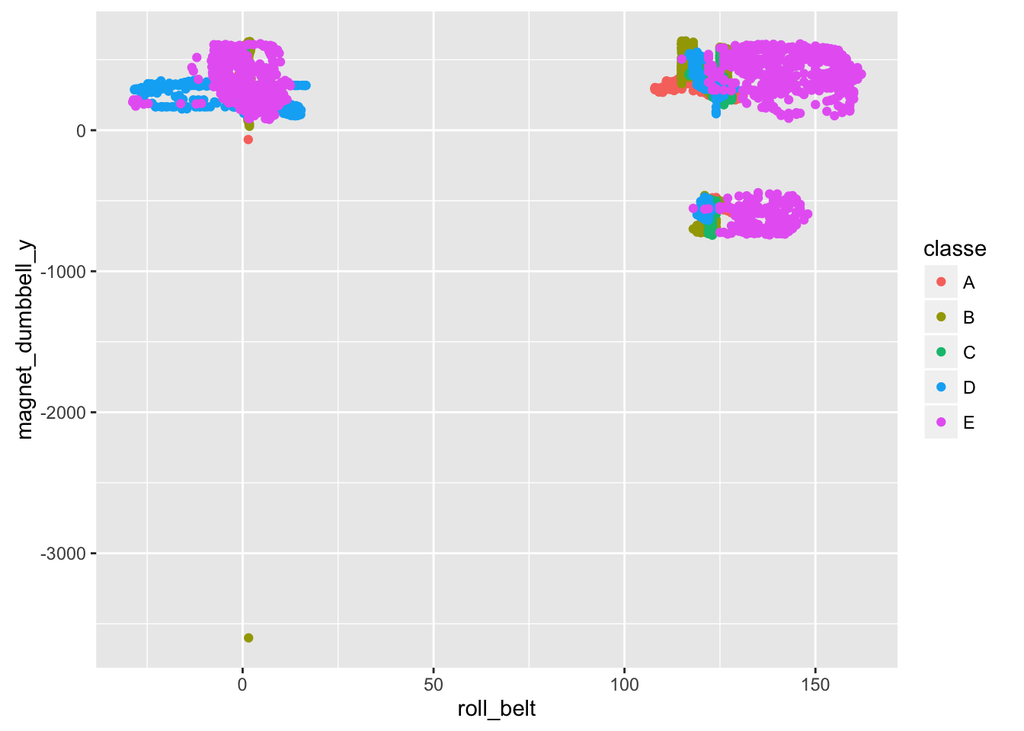

```r
modfit2=randomForest(classe~., data=train2, method='class')
pred2 = predict(modfit2,train2,type='class')
qplot(roll_belt, magnet_dumbbell_y, colour=classe, data=train2)
```

```r
z2=confusionMatrix(pred2,train2$classe)
z2$table
```

```
##           Reference
## Prediction    A    B    C    D    E
##          A 2232    0    0    0    0
##          B    0 1518    0    0    0
##          C    0    0 1368    0    0
##          D    0    0    0 1286    0
##          E    0    0    0    0 1442
```

```r
z2$overall[1]
```

```
## Accuracy
##        1
```

## Conclusion

It’s clear to see from the results above that the Random Forest Method provides the best fit model

```r
pred3 =  predict(modfit2,testing,type='class')
  nofiles = length(pred3)
  for (i in 1:nofiles){
      filename =  paste0("problem_id",i,".txt")
      write.table(pred3[i],file=filename,quote=FALSE,row.names=FALSE,col.names=FALSE)
  }
pred3
```

```
##  1  2  3  4  5  6  7  8  9 10 11 12 13 14 15 16 17 18 19 20
##  B  A  B  A  A  E  D  C  A  A  B  C  B  A  E  E  A  B  B  B
## Levels: A B C D E
```